# Модуль 1

## Подключение библиотек

```python
import pandas as pd
import numpy as np
import matplotlib.pyplot as plt
import warnings
import seaborn as sns
```

# 1. Загрузка данных

### При загрузке данных трех файлов с результатами ультразвукового контроля стандартного образца предприятия(SOP) сразу отбрасываем первую строку, содержащую техническую информацию.

Также необходимо отбросить первый столбец, указывающий джистанци, который по сути равен номеру индекса, т.к. шаг установки равен 1 мм.

Сначала загрузим первый файл SOP1.txt и сразу удалим техническую информацию в первой строке и первом столбце

```python
from google.colab import drive
drive.mount('/content/drive/')
```

## Загрузка SOP1

```python
sop_1 = pd.read_csv("/content/drive/My Drive/brics2020/SOP1.txt", engine="python", sep="	", skiprows=1, header=None)
sop_1 = sop_1.iloc[:,1:]
```

### Загрузка SOP2

```python
sop_2=pd.read_csv("/content/drive/My Drive/brics2020/SOP2.txt", engine="python", sep="	", skiprows=1, header=None)
sop_2=sop_2.iloc[:,1:]
```

### Загрузка SOP3

```python
sop_3=pd.read_csv("/content/drive/My Drive/brics2020/SOP3.txt", engine="python", sep="	", skiprows=1, header=None)
sop_3=sop_3.iloc[:,1:]
```

Выведем первые пять строчек для каждого датафрейма

```python
sop_1.head()
```

|  | 1 | 2 | 3 | 4 | 5 | 6 | 7 | 8 | 9 | 10 | 11 | 12 | 13 | 14 | 15 | 16 | 17 | 18 | 19 | 20 | 21 | 22 | 23 | 24 | 25 | 26 | 27 | 28 | 29 | … |
| --- | --- | --- | --- | --- | --- | --- | --- | --- | --- | --- | --- | --- | --- | --- | --- | --- | --- | --- | --- | --- | --- | --- | --- | --- | --- | --- | --- | --- | --- | --- |
| 0 | 0 | 64 | 202 | 35 | 0 | 27 | 29 | 0 | 255 | 147 | 0 | 86 | 0 | 174 | 80 | 22 | 61 | 202 | 25 | 37 | -1 | -1 | 253 | 145 | -2 | 172 | 78 | 88 | 1 | … |
| 1 | 0 | 59 | 190 | 29 | 0 | 27 | 22 | 0 | 255 | 147 | 0 | 63 | 0 | 163 | 68 | 35 | 62 | 193 | 29 | 32 | 3 | 3 | 255 | 147 | -2 | 160 | 68 | 61 | -2 | … |
| 2 | 0 | 48 | 188 | 13 | 0 | 24 | 10 | 0 | 255 | 145 | 0 | 45 | 0 | 144 | 60 | 18 | 45 | 189 | 27 | 15 | -3 | 2 | 254 | 144 | 1 | 142 | 63 | 46 | 1 | … |
| 3 | 0 | 37 | 183 | 1 | 0 | 26 | 6 | 0 | 255 | 153 | 0 | 61 | 0 | 123 | 76 | 8 | 38 | 180 | 24 | -1 | 3 | 0 | 255 | 155 | 2 | 120 | 77 | 62 | -3 | … |
| 4 | 0 | 31 | 188 | 0 | 0 | 32 | 4 | 0 | 255 | 157 | 0 | 69 | 0 | 111 | 99 | 11 | 28 | 190 | 33 | -1 | -2 | 1 | 252 | 156 | -3 | 108 | 102 | 67 | 1 | … |

Размерность массива данных SOP1

```python
sop_1.shape
```

```
(1100, 41)
```

```python
sop_2.head()
```

|  | 1 | 2 | 3 | 4 | 5 | 6 | 7 | 8 | 9 | 10 | 11 | 12 | 13 | 14 | 15 | 16 | 17 | 18 | 19 | 20 | 21 | 22 | 23 | 24 | 25 | 26 | 27 | 28 | 29 | … |
| --- | --- | --- | --- | --- | --- | --- | --- | --- | --- | --- | --- | --- | --- | --- | --- | --- | --- | --- | --- | --- | --- | --- | --- | --- | --- | --- | --- | --- | --- | --- |
| 0 | 0 | 0 | 175 | 0 | 0 | 12 | 0 | 0 | 255 | 112 | 0 | 0 | 0 | 0 | 122 | 10 | -3 | 175 | 10 | 2 | -1 | -1 | 253 | 110 | -2 | -2 | 120 | 2 | 1 | … |
| 1 | 0 | 0 | 159 | 0 | 0 | 10 | 10 | 0 | 255 | 108 | 0 | 0 | 2 | 0 | 120 | 14 | 3 | 162 | 12 | 3 | 3 | 3 | 255 | 108 | -2 | -3 | 120 | -2 | 0 | … |
| 2 | 0 | 0 | 139 | 0 | 0 | 25 | 48 | 0 | 255 | 145 | 0 | 0 | 0 | 0 | 144 | 36 | -3 | 140 | 28 | 2 | -3 | 2 | 254 | 144 | 1 | % | 147 | 1 | 1 | … |
| 3 | 0 | 0 | 130 | 0 | 0 | 54 | 61 | 0 | 255 | 216 | 0 | 0 | 0 | 0 | 170 | @ | 1 | 127 | 52 | -2 | 3 | 0 | 255 | 218 | 2 | -3 | 171 | 1 | -3 | … |
| 4 | 0 | 0 | 110 | 0 | 0 | 54 | 57 | 0 | 10169 | 207 | 0 | 0 | 21 | 0 | 184 | 34 | -3 | 112 | 55 | -1 | -2 | 1 | 233 | 206 | -3 | -3 | 187 | -2 | 22 | … |

Размерность массива данных SOP2

```python
sop_2.shape
```

```
(1100, 47)
```

```python
sop_3.head()
```

|  | 1 | 2 | 3 | 4 | 5 | 6 | 7 | 8 | 9 | 10 | 11 | 12 | 13 | 14 | 15 | 16 | 17 | 18 | 19 | 20 | 21 | 22 | 23 | 24 | 25 | 26 | 27 | 28 | 29 | … |
| --- | --- | --- | --- | --- | --- | --- | --- | --- | --- | --- | --- | --- | --- | --- | --- | --- | --- | --- | --- | --- | --- | --- | --- | --- | --- | --- | --- | --- | --- | --- |
| 0 | 0 | 0 | 0 | 56 | 0 | 10 | 148 | 0 | 39 | 118 | 0 | 0 | 0 | 29 | 66 | 0 | -3 | 0 | 8 | 58 | -1 | -1 | 37 | 116 | -2 | 27 | 64 | 2 | 1 | … |
| 1 | 0 | 0 | 0 | 55 | 0 | 28 | 129 | 0 | 48 | 150 | 0 | 0 | 0 | 33 | 74 | 1 | 3 | 3 | 30 | 58 | 3 | 3 | 48 | 150 | -2 | 30 | 74 | -2 | -2 | … |
| 2 | 0 | 0 | 0 | 58 | 0 | 48 | 94 | 0 | 16 | 210 | 0 | 0 | 0 | 28 | 87 | 5 | -3 | 1 | 51 | 60 | -3 | 2 | 15 | 209 | 1 | 26 | 90 | 1 | 1 | … |
| 3 | 0 | 0 | 0 | 51 | 0 | 54 | 68 | 0 | 18 | 244 | 0 | 0 | 0 | 21 | 96 | 13 | 1 | -3 | 52 | 49 | 3 | 0 | 18 | 246 | 2 | 18 | 97 | 1 | -3 | … |
| 4 | 0 | 0 | 0 | 36 | 0 | 81 | 46 | 0 | 16 | 255 | 0 | 0 | 0 | 12 | 94 | 25 | -3 | 2 | 82 | 35 | -2 | 1 | 13 | 254 | -3 | 9 | 97 | -2 | 1 | … |

Размерность массива данных SOP3

```python
sop_3.shape
```

[output not shown]

В данных присутствуют столбецы, которых не должно быть, так как из описания ПУЗК известно, что схем прозвучивания 16 Удалим лишние столбцы

```python
for i in range(17, 42, 1):
  sop_1.drop(columns=i, inplace=True)
```

```python
for i in range(17, 48, 1):
  sop_2.drop(columns=i, inplace=True)
```

```python
for i in range(17, 42, 1):
  sop_3.drop(columns=i, inplace=True)
```

По заданию в длина шварного шва 1020 мм, а строк в данных 1100. Значит имеем нахлёст 80 мм, кoторый нужно убрать

```python
for i in range(1020, 1100, 1):
  sop_1.drop(index=i, inplace=True)
```

```python
for i in range(1020, 1100, 1):
  sop_2.drop(index=i, inplace=True)
```

```python
for i in range(1020, 1100, 1):
  sop_3.drop(index=i, inplace=True)
```

Посмотрим на данные после удаления строк столбцов:

```python
sop_1.head()
```

|  | 1 | 2 | 3 | 4 | 5 | 6 | 7 | 8 | 9 | 10 | 11 | 12 | 13 | 14 | 15 | 16 |
| --- | --- | --- | --- | --- | --- | --- | --- | --- | --- | --- | --- | --- | --- | --- | --- | --- |
| 0 | 0 | 64 | 202 | 35 | 0 | 27 | 29 | 0 | 255 | 147 | 0 | 86 | 0 | 174 | 80 | 22 |
| 1 | 0 | 59 | 190 | 29 | 0 | 27 | 22 | 0 | 255 | 147 | 0 | 63 | 0 | 163 | 68 | 35 |
| 2 | 0 | 48 | 188 | 13 | 0 | 24 | 10 | 0 | 255 | 145 | 0 | 45 | 0 | 144 | 60 | 18 |
| 3 | 0 | 37 | 183 | 1 | 0 | 26 | 6 | 0 | 255 | 153 | 0 | 61 | 0 | 123 | 76 | 8 |
| 4 | 0 | 31 | 188 | 0 | 0 | 32 | 4 | 0 | 255 | 157 | 0 | 69 | 0 | 111 | 99 | 11 |

```python
sop_1.tail()
```

|  | 1 | 2 | 3 | 4 | 5 | 6 | 7 | 8 | 9 | 10 | 11 | 12 | 13 | 14 | 15 | 16 |
| --- | --- | --- | --- | --- | --- | --- | --- | --- | --- | --- | --- | --- | --- | --- | --- | --- |
| 1015 | 0 | 131 | 238 | 116 | 0 | 12 | 134 | 0 | 255 | 112 | 0 | 0 | 0 | 255 | 11 | 13 |
| 1016 | 0 | 126 | 241 | 102 | 0 | 34 | 137 | 0 | 255 | 168 | 0 | 0 | 0 | 255 | 26 | & |
| 1017 | 0 | 120 | 230 | 89 | 0 | 50 | 116 | 0 | 255 | 210 | 0 | 2 | 0 | 255 | 45 | 0 |
| 1018 | 0 | @ | 199 | 76 | 0 | 72 | 86 | 0 | 255 | 251 | 0 | 25 | 0 | 249 | 61 | 37 |
| 1019 | 0 | 85 | 164 | 66 | 5 | 90 | 61 | 0 | 255 | 255 | 0 | 45 | 0 | 212 | 72 | 6 |

```python
sop_2.head()
```

|  | 1 | 2 | 3 | 4 | 5 | 6 | 7 | 8 | 9 | 10 | 11 | 12 | 13 | 14 | 15 | 16 |
| --- | --- | --- | --- | --- | --- | --- | --- | --- | --- | --- | --- | --- | --- | --- | --- | --- |
| 0 | 0 | 0 | 175 | 0 | 0 | 12 | 0 | 0 | 255 | 112 | 0 | 0 | 0 | 0 | 122 | 10 |
| 1 | 0 | 0 | 159 | 0 | 0 | 10 | 10 | 0 | 255 | 108 | 0 | 0 | 2 | 0 | 120 | 14 |
| 2 | 0 | 0 | 139 | 0 | 0 | 25 | 48 | 0 | 255 | 145 | 0 | 0 | 0 | 0 | 144 | 36 |
| 3 | 0 | 0 | 130 | 0 | 0 | 54 | 61 | 0 | 255 | 216 | 0 | 0 | 0 | 0 | 170 | @ |
| 4 | 0 | 0 | 110 | 0 | 0 | 54 | 57 | 0 | 10169 | 207 | 0 | 0 | 21 | 0 | 184 | 34 |

```python
sop_2.tail()
```

|  | 1 | 2 | 3 | 4 | 5 | 6 | 7 | 8 | 9 | 10 | 11 | 12 | 13 | 14 | 15 | 16 |
| --- | --- | --- | --- | --- | --- | --- | --- | --- | --- | --- | --- | --- | --- | --- | --- | --- |
| 1015 | 0 | 0 | 0 | 0 | 0 | 0 | 0 | 0 | 21 | 48 | 0 | 49 | 0 | 0 | 42 | 1 |
| 1016 | 0 | 0 | 0 | 0 | 0 | 0 | 0 | 0 | 27 | 64 | 0 | 31 | 0 | 0 | 75 | 8 |
| 1017 | 0 | 0 | 0 | 0 | 5 | 7 | 0 | 0 | 33 | 104 | 0 | 17 | 0 | 0 | 95 | 1 |
| 1018 | 0 | 0 | 23 | 0 | 0 | 16 | 0 | 0 | 45 | 128 | 0 | 2 | 0 | 0 | 121 | 0 |
| 1019 | 0 | 0 | 3 | 0 | 0 | 5 | 0 | 0 | 50 | 100 | 0 | 0 | 0 | 0 | 141 | 0 |

```python
sop_3.head()
```

|  | 1 | 2 | 3 | 4 | 5 | 6 | 7 | 8 | 9 | 10 | 11 | 12 | 13 | 14 | 15 | 16 |
| --- | --- | --- | --- | --- | --- | --- | --- | --- | --- | --- | --- | --- | --- | --- | --- | --- |
| 0 | 0 | 0 | 0 | 56 | 0 | 10 | 148 | 0 | 39 | 118 | 0 | 0 | 0 | 29 | 66 | 0 |
| 1 | 0 | 0 | 0 | 55 | 0 | 28 | 129 | 0 | 48 | 150 | 0 | 0 | 0 | 33 | 74 | 1 |
| 2 | 0 | 0 | 0 | 58 | 0 | 48 | 94 | 0 | 16 | 210 | 0 | 0 | 0 | 28 | 87 | 5 |
| 3 | 0 | 0 | 0 | 51 | 0 | 54 | 68 | 0 | 18 | 244 | 0 | 0 | 0 | 21 | 96 | 13 |
| 4 | 0 | 0 | 0 | 36 | 0 | 81 | 46 | 0 | 16 | 255 | 0 | 0 | 0 | 12 | 94 | 25 |

```python
sop_3.tail()
```

|  | 1 | 2 | 3 | 4 | 5 | 6 | 7 | 8 | 9 | 10 | 11 | 12 | 13 | 14 | 15 | 16 |
| --- | --- | --- | --- | --- | --- | --- | --- | --- | --- | --- | --- | --- | --- | --- | --- | --- |
| 1015 | 0 | 0 | 0 | 80 | 0 | 0 | 209 | 0 | 5 | 40 | 0 | 60 | 0 | 24 | 79 | 12 |
| 1016 | 0 | 0 | 0 | 98 | 0 | 0 | 184 | 0 | 3 | 49 | 0 | 37 | 0 | NaN | 77 | 22 |
| 1017 | 0 | 0 | 0 | 112 | 0 | 0 | 155 | 0 | 13 | 55 | 0 | 19 | 0 | 48 | 72 | 0 |
| 1018 | 0 | 0 | 0 | 90 | 0 | 0 | 149 | 0 | 0 | 71 | 0 | 0 | 0 | 40 | 65 | 0 |
| 1019 | 0 | 0 | 0 | 60 | 0 | 0 | 161 | 0 | 23 | 70 | 0 | 0 | 26 | 33 | 63 | 0 |

Проверка наличие пропущенные значений (NaN):

```python
sop_1.isna().sum()
```

```
1     4
2     4
3     4
4     4
5     4
6     4
7     4
8     4
9     4
10    4
11    3
12    4
13    4
14    4
15    4
16    4
dtype: int64
```

```python
sop_2.isna().sum()
```

```
1     4
2     5
3     4
4     5
5     4
6     2
7     5
8     4
9     4
10    4
11    4
12    4
13    5
14    4
15    4
16    5
dtype: int64
```

```python
sop_3.isna().sum()
```

```
1     5
2     4
3     3
4     4
5     5
6     3
7     4
8     6
9     4
10    6
11    4
12    5
13    4
14    4
15    4
16    5
dtype: int64
```

Видим, что у нас имеются пропущенные значения, заменим их на 0

```python
for i in range(1, 17, 1):
  sop_1[i].fillna(0, inplace=True)
```

```python
for i in range(1, 17, 1):
  sop_2[i].fillna(0, inplace=True)
```

```python
for i in range(1, 17, 1):
  sop_3[i].fillna(0, inplace=True)
```

```python
sop_1.isna().sum()
```

```
1     0
2     0
3     0
4     0
5     0
6     0
7     0
8     0
9     0
10    0
11    0
12    0
13    0
14    0
15    0
16    0
dtype: int64
```

```python
sop_2.isna().sum()
```

```
1     0
2     0
3     0
4     0
5     0
6     0
7     0
8     0
9     0
10    0
11    0
12    0
13    0
14    0
15    0
16    0
dtype: int64
```

```python
sop_3.isna().sum()
```

```
1     0
2     0
3     0
4     0
5     0
6     0
7     0
8     0
9     0
10    0
11    0
12    0
13    0
14    0
15    0
16    0
dtype: int64
```

Теперь пропусков данных нет

Типы данных по тактам:

```python
sop_1.dtypes
```

```
1     object
2     object
3     object
4     object
5     object
6     object
7     object
8     object
9     object
10    object
11    object
12    object
13    object
14    object
15    object
16    object
dtype: object
```

```python
sop_2.dtypes
```

```
1     object
2     object
3     object
4     object
5     object
6     object
7     object
8     object
9     object
10    object
11    object
12    object
13    object
14    object
15    object
16    object
dtype: object
```

```python
sop_3.dtypes
```

```
1     object
2     object
3     object
4     object
5     object
6     object
7     object
8     object
9     object
10    object
11    object
12    object
13    object
14    object
15    object
16    object
dtype: object
```

Имеется такты неправильного типа. Приведём данные этих столбцов к нужному типу:

```python
for i in range(1, 17, 1):
  sop_1[i] = pd.to_numeric(sop_1[i], errors='coerce')
```

```python
for i in range(1, 17, 1):
  sop_2[i] = pd.to_numeric(sop_2[i], errors='coerce')
```

```python
for i in range(1, 17, 1):
  sop_3[i] = pd.to_numeric(sop_3[i], errors='coerce')
```

```python
sop_1.dtypes
```

```
1     float64
2     float64
3     float64
4     float64
5     float64
6     float64
7     float64
8     float64
9     float64
10    float64
11    float64
12    float64
13    float64
14    float64
15    float64
16    float64
dtype: object
```

```python
sop_2.dtypes
```

```
1     float64
2     float64
3     float64
4     float64
5     float64
6     float64
7     float64
8     float64
9     float64
10    float64
11    float64
12    float64
13    float64
14    float64
15    float64
16    float64
dtype: object
```

```python
sop_3.dtypes
```

```
1     float64
2     float64
3     float64
4     float64
5     float64
6     float64
7     float64
8     float64
9     float64
10    float64
11    float64
12    float64
13    float64
14    float64
15    float64
16    float64
dtype: object
```

```python
print('Количесто строк и столбцов:')
print('СОП №1: {} {}\n'.format(sop_1.shape[0], sop_1.shape[1]),
      'СОП №2: {} {}\n'.format(sop_2.shape[0], sop_2.shape[1]),
      'СОП №3: {} {}\n'.format(sop_3.shape[0], sop_3.shape[1]))
```

```
Количесто строк и столбцов:
СОП №1: 1020 16
 СОП №2: 1020 16
 СОП №3: 1020 16
```

# 2. ПРЕДВАРИТЕЛЬНОЕ ИЗУЧЕНИЕ

## 2.1 Анализ переменных в табличном виде максимальное, минимальное значение, среднеквадратичное отклонение, медиана, квартили)

### Таблица статистического анализа переменных для SOP1

```python
sop_1.describe().T
```

|  | count | mean | std | min | 25% | 50% | 75% | max |
| --- | --- | --- | --- | --- | --- | --- | --- | --- |
| 1 | 1015.0 | 30.633498 | 552.284449 | 0.0 | 0.0 | 0.0 | 0.0 | 10169.0 |
| 2 | 1015.0 | 5.720197 | 19.341133 | 0.0 | 0.0 | 0.0 | 0.0 | 141.0 |
| 3 | 1015.0 | 33.311330 | 55.966104 | 0.0 | 0.0 | 9.0 | 37.5 | 255.0 |
| 4 | 1015.0 | 119.286700 | 86.151520 | 0.0 | 38.0 | 117.0 | 196.0 | 255.0 |
| 5 | 1015.0 | 0.468966 | 3.520687 | 0.0 | 0.0 | 0.0 | 0.0 | 63.0 |
| 6 | 1015.0 | 15.449261 | 49.171149 | 0.0 | 0.0 | 0.0 | 0.0 | 255.0 |
| 7 | 1015.0 | 96.785222 | 64.321916 | 0.0 | 45.0 | 93.0 | 140.0 | 255.0 |
| 8 | 1015.0 | 1.140905 | 7.320960 | 0.0 | 0.0 | 0.0 | 0.0 | 72.0 |
| 9 | 1015.0 | 86.389163 | 71.261798 | 0.0 | 36.0 | 63.0 | 111.0 | 255.0 |
| 10 | 1015.0 | 60.454187 | 71.061573 | 0.0 | 16.0 | 35.0 | 70.0 | 255.0 |
| 11 | 1015.0 | 6.000000 | 18.701644 | 0.0 | 0.0 | 0.0 | 0.0 | 145.0 |
| 12 | 1015.0 | 69.748768 | 74.676930 | 0.0 | 0.0 | 48.0 | 117.0 | 255.0 |
| 13 | 1015.0 | 5.127094 | 11.980614 | 0.0 | 0.0 | 0.0 | 4.0 | 66.0 |
| 14 | 1015.0 | 28.158621 | 48.743072 | 0.0 | 0.0 | 9.0 | 32.5 | 255.0 |
| 15 | 1015.0 | 63.319212 | 60.699916 | 0.0 | 6.0 | 52.0 | 101.0 | 255.0 |
| 16 | 1015.0 | 17.512315 | 23.303071 | 0.0 | 0.0 | 10.0 | 26.0 | 189.0 |

### Таблица статистического анализа переменных для SOP2

```python
sop_2.describe().T
```

|  | count | mean | std | min | 25% | 50% | 75% | max |
| --- | --- | --- | --- | --- | --- | --- | --- | --- |
| 1 | 1015.0 | 0.596059 | 4.523485 | 0.0 | 0.0 | 0.0 | 0.0 | 47.0 |
| 2 | 1015.0 | 4.784236 | 18.049399 | 0.0 | 0.0 | 0.0 | 0.0 | 115.0 |
| 3 | 1015.0 | 11.333990 | 34.140789 | 0.0 | 0.0 | 0.0 | 1.0 | 255.0 |
| 4 | 1015.0 | 73.495567 | 68.203907 | 0.0 | 6.0 | 60.0 | 120.0 | 255.0 |
| 5 | 1015.0 | 0.744828 | 7.388948 | 0.0 | 0.0 | 0.0 | 0.0 | 152.0 |
| 6 | 1015.0 | 14.520197 | 48.408817 | 0.0 | 0.0 | 0.0 | 0.0 | 255.0 |
| 7 | 1015.0 | 69.279803 | 64.087038 | 0.0 | 15.0 | 55.0 | 107.0 | 255.0 |
| 8 | 1015.0 | 1.205911 | 7.657998 | 0.0 | 0.0 | 0.0 | 0.0 | 84.0 |
| 9 | 1015.0 | 71.619704 | 552.660391 | 0.0 | 9.0 | 24.0 | 50.0 | 10169.0 |
| 10 | 1015.0 | 53.427604 | 70.562983 | 0.0 | 7.5 | 30.0 | 61.0 | 255.0 |
| 11 | 1015.0 | 4.632512 | 18.115124 | 0.0 | 0.0 | 0.0 | 0.0 | 147.0 |
| 12 | 1015.0 | 49.686700 | 68.456600 | 0.0 | 0.0 | 17.0 | 77.0 | 255.0 |
| 13 | 1015.0 | 5.639409 | 12.686013 | 0.0 | 0.0 | 0.0 | 4.0 | 93.0 |
| 14 | 1015.0 | 26.194089 | 46.519839 | 0.0 | 0.0 | 8.0 | 31.0 | 255.0 |
| 15 | 1015.0 | 59.601970 | 57.166796 | 0.0 | 6.0 | 45.0 | 97.0 | 239.0 |
| 16 | 1015.0 | 19.441379 | 24.735290 | 0.0 | 1.0 | 13.0 | 28.0 | 203.0 |

### Таблица статистического анализа переменных для SOP3

```python
sop_3.describe().T
```

|  | count | mean | std | min | 25% | 50% | 75% | max |
| --- | --- | --- | --- | --- | --- | --- | --- | --- |
| 1 | 1015.0 | 0.798030 | 4.436001 | 0.0 | 0.0 | 0.0 | 0.0 | 43.0 |
| 2 | 1016.0 | 19.665354 | 49.902074 | 0.0 | 0.0 | 0.0 | 3.0 | 255.0 |
| 3 | 1015.0 | 51.429557 | 553.882677 | 0.0 | 0.0 | 0.0 | 7.0 | 10169.0 |
| 4 | 1015.0 | 81.134975 | 61.523336 | 0.0 | 29.0 | 77.0 | 118.5 | 255.0 |
| 5 | 1015.0 | 1.060099 | 5.792375 | 0.0 | 0.0 | 0.0 | 0.0 | 64.0 |
| 6 | 1015.0 | 14.746798 | 37.599361 | 0.0 | 0.0 | 0.0 | 6.5 | 239.0 |
| 7 | 1015.0 | 151.393103 | 85.515724 | 0.0 | 80.0 | 159.0 | 239.5 | 255.0 |
| 8 | 1015.0 | 1.227586 | 9.226945 | 0.0 | 0.0 | 0.0 | 0.0 | 123.0 |
| 9 | 1015.0 | 49.469951 | 70.060968 | 0.0 | 3.0 | 20.0 | 57.5 | 255.0 |
| 10 | 1015.0 | 88.479803 | 78.257360 | 0.0 | 36.0 | 60.0 | 105.5 | 255.0 |
| 11 | 1015.0 | 6.641379 | 19.617834 | 0.0 | 0.0 | 0.0 | 0.0 | 135.0 |
| 12 | 1015.0 | 147.333005 | 84.149015 | 0.0 | 81.0 | 152.0 | 227.5 | 255.0 |
| 13 | 1015.0 | 16.598030 | 22.061819 | 0.0 | 0.0 | 9.0 | 24.0 | 163.0 |
| 14 | 1015.0 | 56.444353 | 75.976552 | 0.0 | 10.0 | 27.0 | 58.5 | 255.0 |
| 15 | 1015.0 | 72.749754 | 59.143029 | 0.0 | 22.0 | 65.0 | 111.0 | 244.0 |
| 16 | 1015.0 | 15.289655 | 25.600998 | 0.0 | 0.0 | 8.0 | 23.0 | 255.0 |

### Визуализация статистических показателей

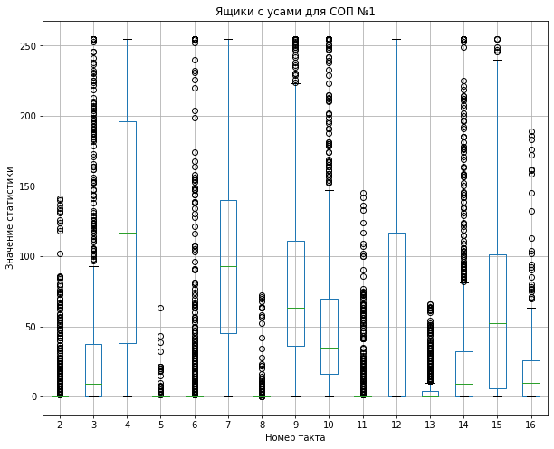

```python
sop_1.iloc[:, 1:].boxplot(figsize=(10, 8))
plt.title('Ящики с усами для СОП №1')
plt.ylabel('Значение статистики')
plt.xlabel('Номер такта');
```

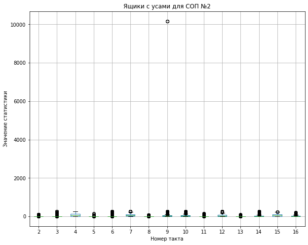

```python
sop_2.iloc[:, 1:].boxplot(figsize=(10, 8))
plt.title('Ящики с усами для СОП №2')
plt.ylabel('Значение статистики')
plt.xlabel('Номер такта');
```

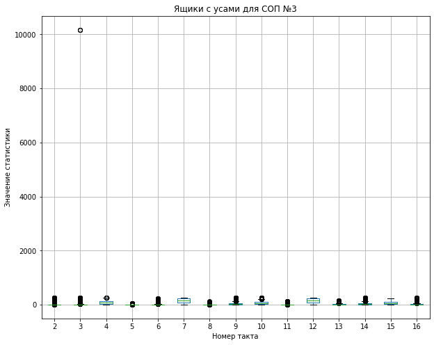

```python
sop_3.iloc[:, 1:].boxplot(figsize=(10, 8))
plt.title('Ящики с усами для СОП №3')
plt.ylabel('Значение статистики')
plt.xlabel('Номер такта');
```

### Гистограммы значений сигналов:

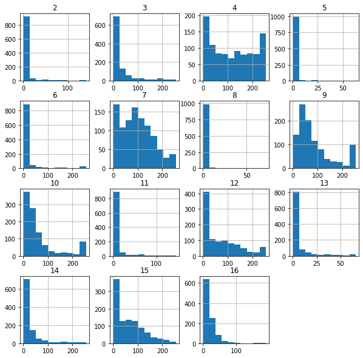

```python
sop_1.iloc[:, 1:].hist(figsize=(10, 10));
```

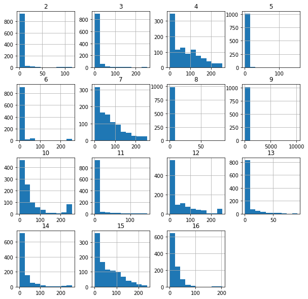

```python
sop_2.iloc[:, 1:].hist(figsize=(10, 10));
```

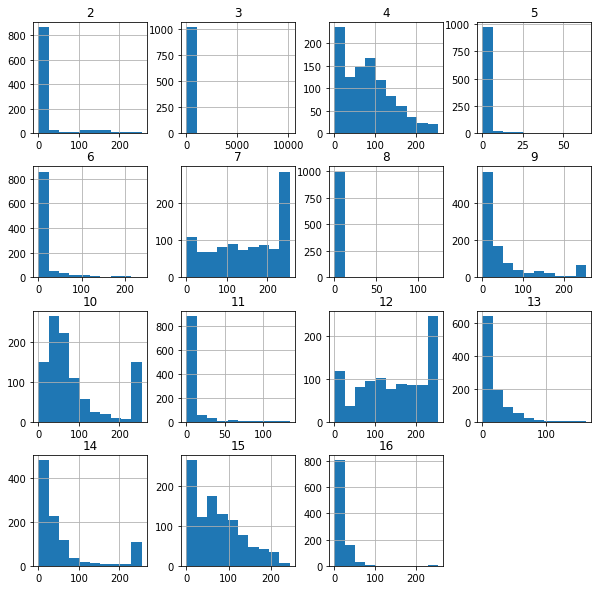

```python
sop_3.iloc[:, 1:].hist(figsize=(10, 10));
```

### Визуализация показаний всеx тактов

#### СОП №1

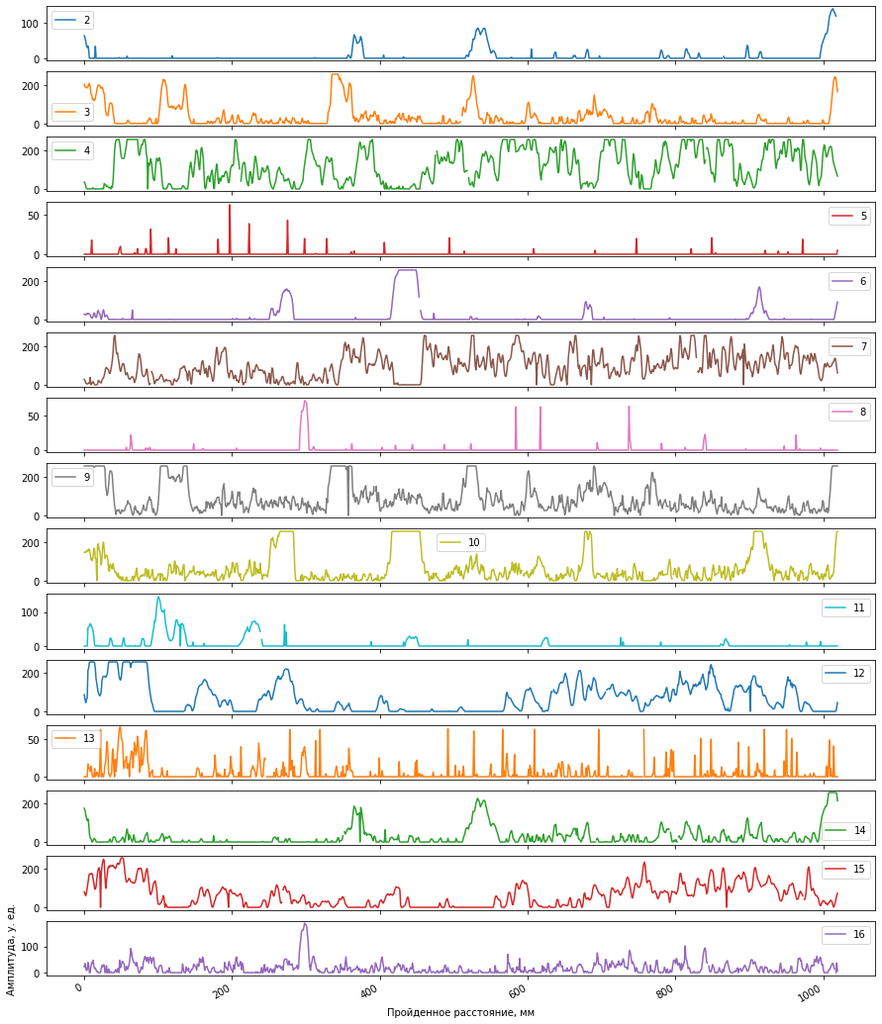

```python
sop_1.iloc[:, 1:].plot(subplots=True, figsize=(15, 20), sharex=True)
plt.ylabel('Амплитуда, у. ед.')
plt.xlabel('Пройденное расстояние, мм');
```

#### СОП №2

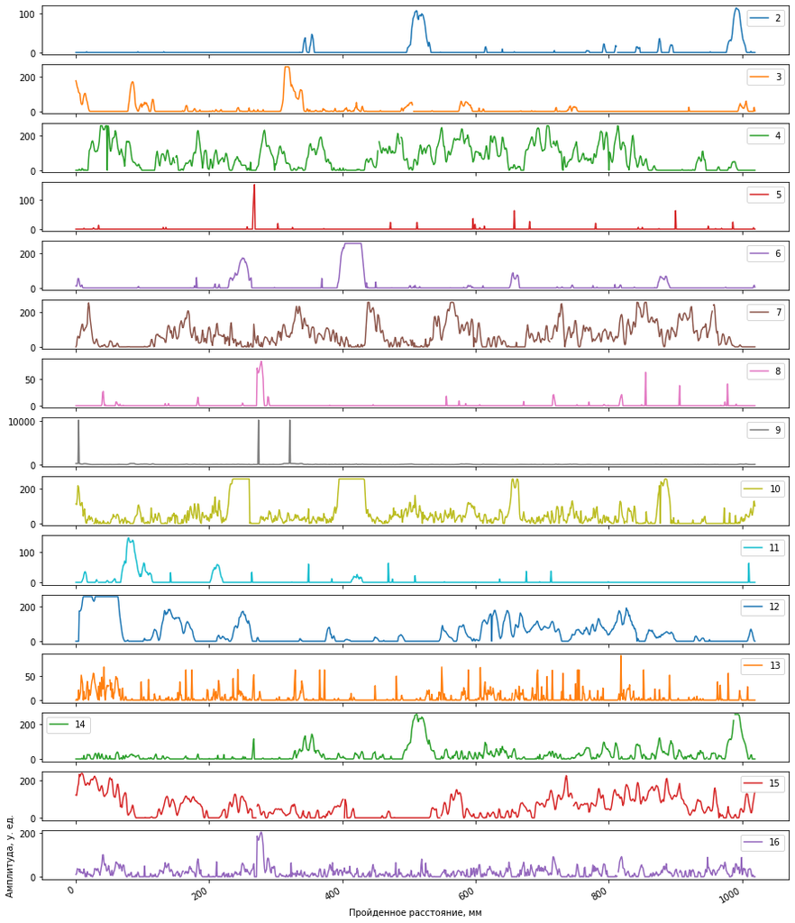

```python
sop_2.iloc[:, 1:].plot(subplots=True, figsize=(15, 20), sharex=True)
plt.ylabel('Амплитуда, у. ед.')
plt.xlabel('Пройденное расстояние, мм');
```

#### СОП №3

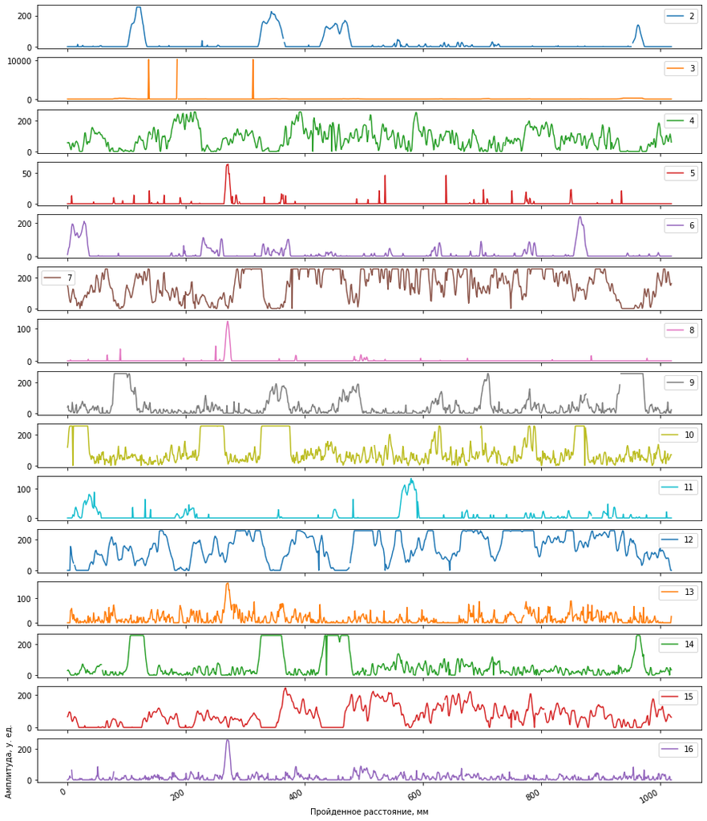

```python
sop_3.iloc[:, 1:].plot(subplots=True, figsize=(15, 20), sharex=True)
plt.ylabel('Амплитуда, у. ед.')
plt.xlabel('Пройденное расстояние, мм');
```

# 3. Определение методов контроля

[figure not shown]

## 3.1 Сглаживание массивов данных

```python
from statsmodels.nonparametric.smoothers_lowess import lowess
from matplotlib import pyplot as plt
```

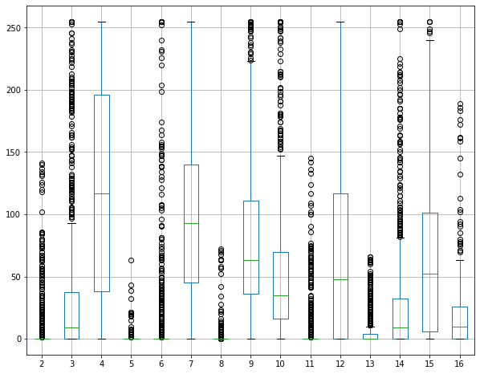

```python
sop = sop_1.copy()
sop.iloc[:1, 1:] = (sop_1.iloc[:, 1:] + sop_2.iloc[:, 1:] + sop_3.iloc[:, 1:]) / 3.
sop.iloc[:, 1:].boxplot(figsize=(10, 8));
```

[figure not shown]

```python
plt.figure(figsize=(15,15))
for ind, col in enumerate(sop_smooth.columns):
    plt.subplot(5,4, ind+1)
    plt.plot(sop_smooth[col])
    plt.title(col)
    plt.xlabel("Distance, mm")
    plt.ylabel("Amplitude")
    plt.tight_layout()
```

Создаем копии датафреймов, которые будем заполнять впоследствии сглаженными значениями.

```python
sop_smooth = sop.copy()
```

Проведем отбор наилучшего метода сглаживания.